# Red wine exploration by Andre Marais

### Multivariate plots

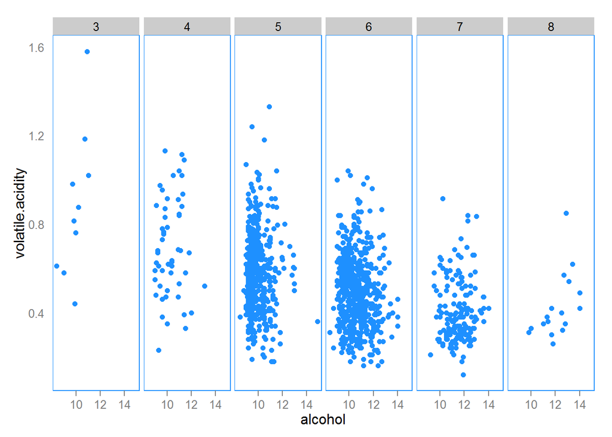

It looks the alcohol variance is much higher with higher quality wines.

```
##   quality   alcohol
## 1       3 0.6691389
## 2       4 0.8738062
## 3       5 0.5424631
## 4       6 1.1017419
## 5       7 0.9253151
## 6       8 1.4982026
```

The variance in fact higher with the better quality wines.

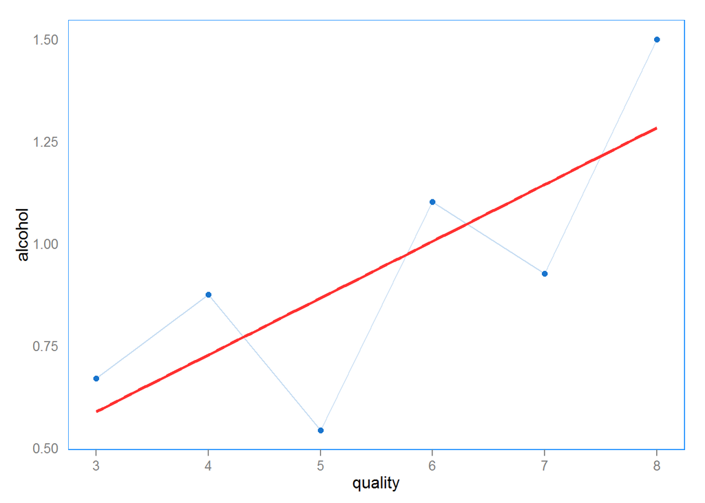

```
##   quality volatile.acidity
## 1       3       0.10973028
## 2       4       0.04844842
## 3       5       0.02715943
## 4       6       0.02590885
## 5       7       0.02109011
## 6       8       0.02100000
```

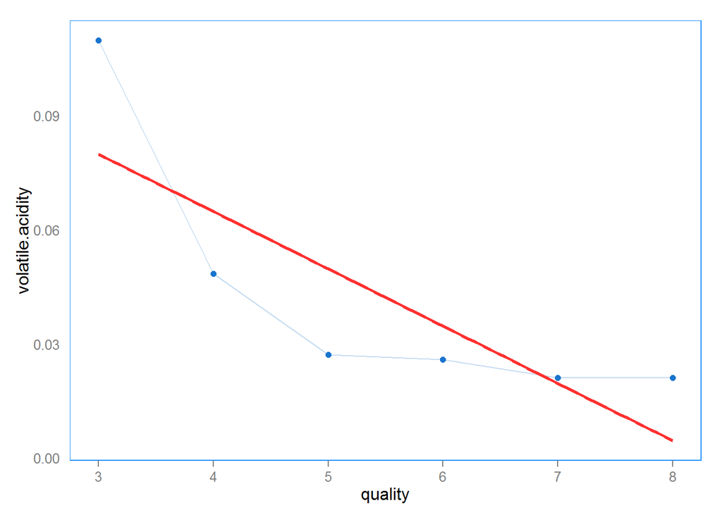

Volatile acidity’s variance decrease with higher quality wines.

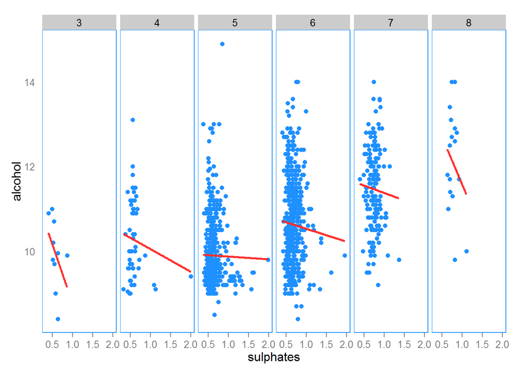

The correlation between alcohol and sulphates differ quite significantly between the different qualities

```
## [1] "Quality:3|correlation: -0.416332"
## [1] "Quality:4|correlation: -0.137167"
## [1] "Quality:5|correlation: -0.015282"
## [1] "Quality:6|correlation: -0.046248"
## [1] "Quality:7|correlation: -0.049359"
## [1] "Quality:8|correlation: -0.212935"
```

Significant correlation only appears at qualities with small samples.

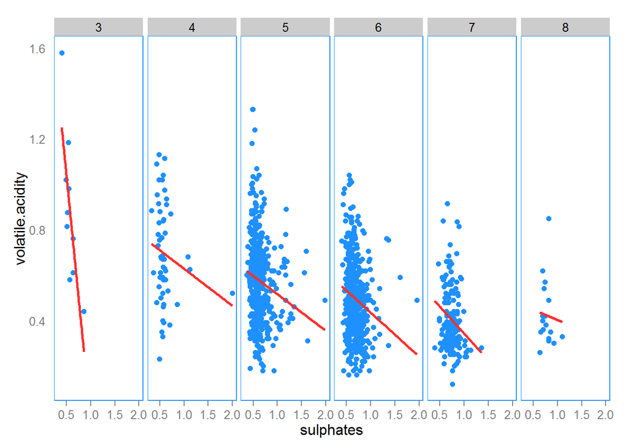

Correlations seems relatively constant between different qualities

```
## [1] "Quality:3|correlation: -0.792241"
## [1] "Quality:4|correlation: -0.177444"
## [1] "Quality:5|correlation: -0.166929"
## [1] "Quality:6|correlation: -0.191156"
## [1] "Quality:7|correlation: -0.221008"
## [1] "Quality:8|correlation: -0.072005"
```

Barring quality 3, they tend to stay constant.

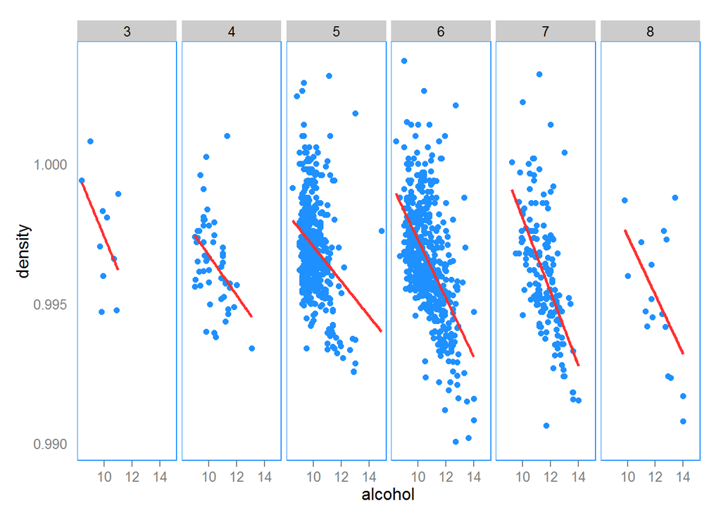

```
## [1] "Quality:3|correlation: -0.490591"
## [1] "Quality:4|correlation: -0.424285"
## [1] "Quality:5|correlation: -0.288762"
## [1] "Quality:6|correlation: -0.547123"
## [1] "Quality:7|correlation: -0.581718"
## [1] "Quality:8|correlation: -0.543465"
```

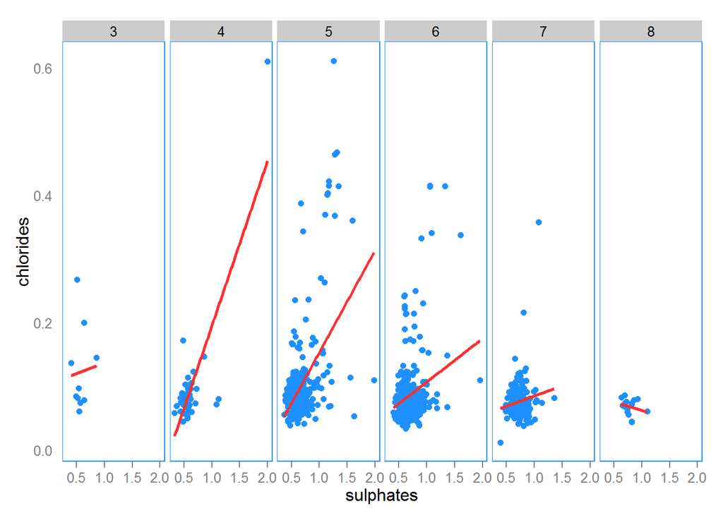

```
## [1] "Quality:3|correlation: 0.061448"
## [1] "Quality:4|correlation: 0.812864"
## [1] "Quality:5|correlation: 0.509021"
## [1] "Quality:6|correlation: 0.271973"
## [1] "Quality:7|correlation: 0.146729"
## [1] "Quality:8|correlation: -0.267275"
```

Heavy variation in the correlation between the different qualities.

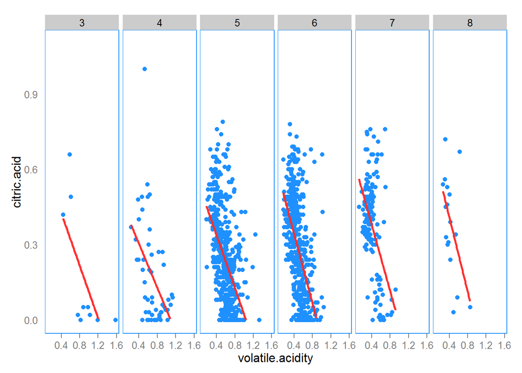

```
## [1] "Quality:3|correlation: -0.692684"
## [1] "Quality:4|correlation: -0.482117"
## [1] "Quality:5|correlation: -0.482535"
## [1] "Quality:6|correlation: -0.572039"
## [1] "Quality:7|correlation: -0.492183"
## [1] "Quality:8|correlation: -0.540887"
```

Correlations seem to be quite constant.

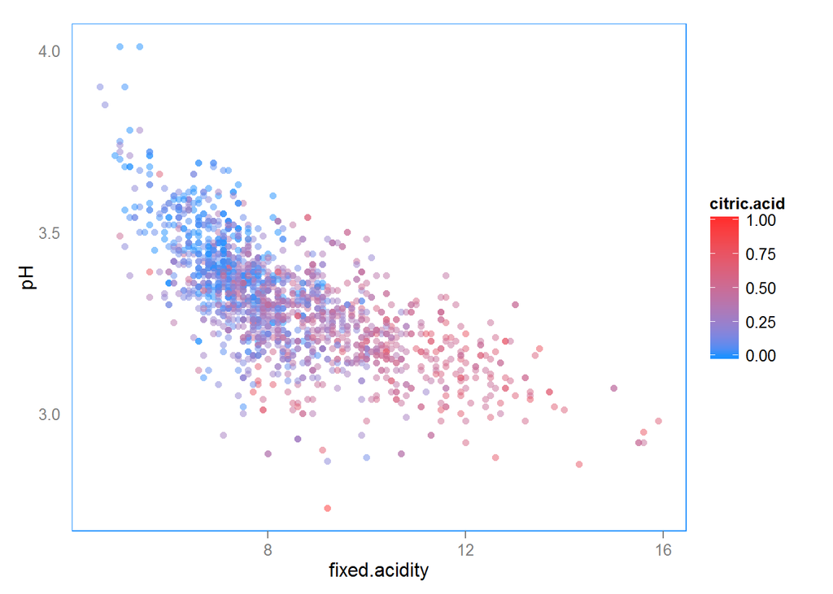

Really not a surprise to see the high correlation between pH, fixed acidity and citric acid levels.

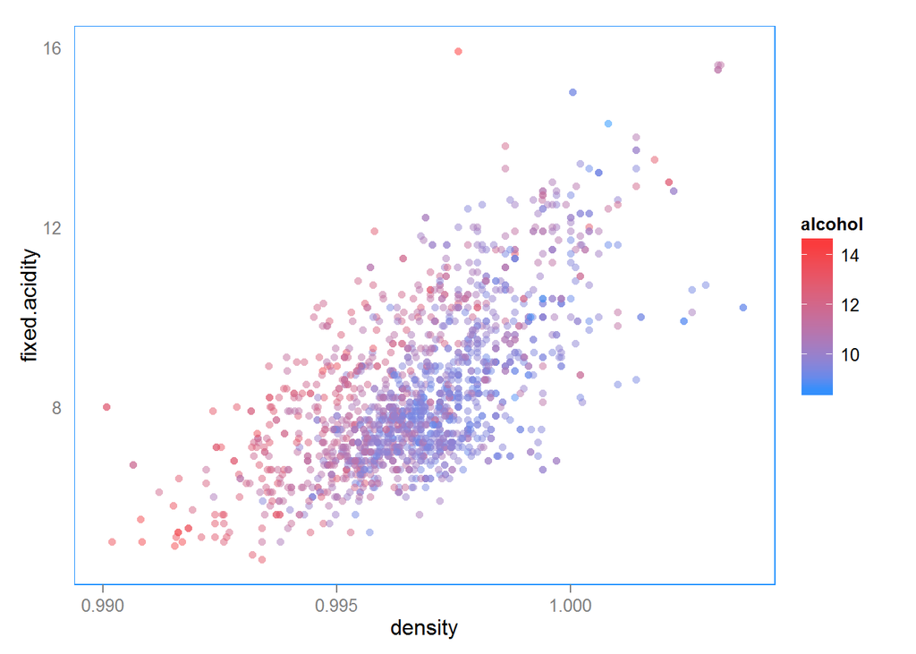

Strong correlation between density and fixed acidity. A blue shift (lower alcohol) with higher density levels.

### Multivariate analysis

It looks like alcohol, sulphates and volatile acidity can be good predictors for quality. It’s worthwhile to see if density, chlorides and citric acid improves the accuracy of the model. Linear models require a continuous response variable, so using quality as a factor is not possible. Instead, I’ll use quality as a numeric value, and round the predicted value to the closest integer instead. I doubt it will be accurate, but it’s worth a shot anyways.

```
## pred.corr
## FALSE  TRUE
##   668   931
```

```
## [1] 0.5822389
```

58% of the wines were predicted accurately only using alcohol, sulphates and volatile acidity

```
## pred.corr
## FALSE  TRUE
##   663   936
```

```
## [1] 0.5853659
```

```
## pred.corr
## FALSE  TRUE
##   473  1126
```

```
## [1] 0.7041901
```

Comparing this to a Random Forest model, it’s quite shocking to see how far we are from a good model. Using a linear model was bit of a long shot, but I don’t think it performed too poorly.

### Final Plots and Summary

#### Plot one

[figure not shown]

#### Description one

There are two things I like about this plot. The first is to show that people tend to give wines with higher alcohol content a higher rating. There are obviously wines with a high alcohol content with lower ratings (4 and less), but there is a definite link between the rating and alcohol content. The second so to see how many outliers there are with wines with a quality rating of 5. I think this is due to the judges defaulting to an ‘average’ rating when they’re not entirely sure where to place the wine. In a way it echos ‘there is no such thing as a bad wine, all wines are average at the very least. Unless it’s a bad wine’.

#### Plot two

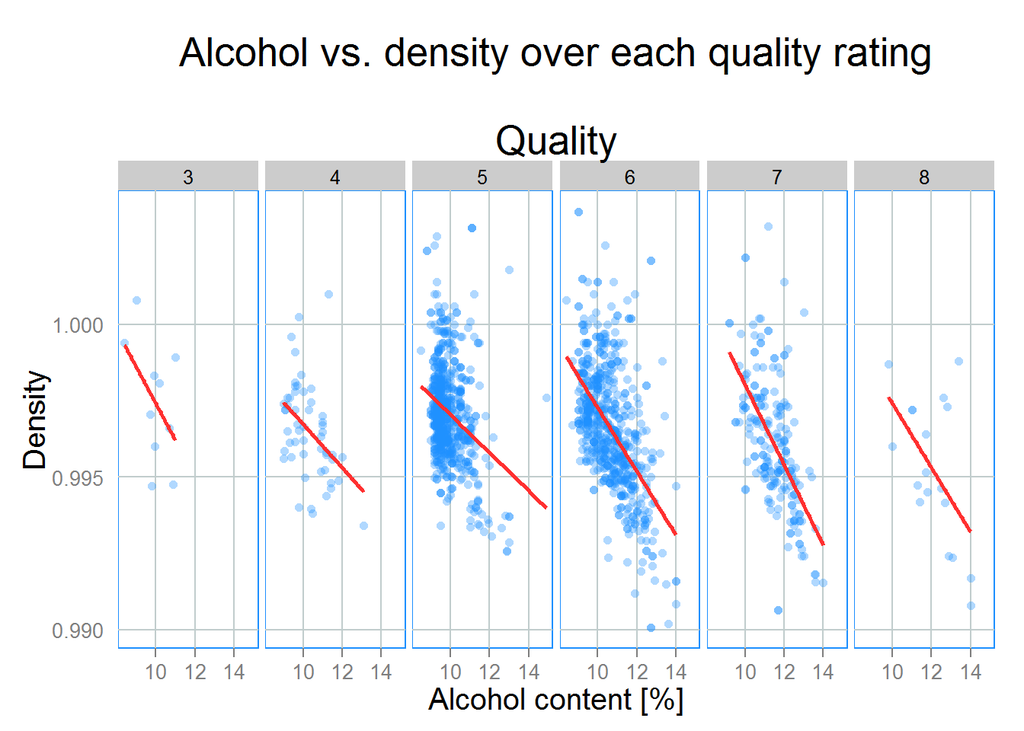

#### Description two

It’s interesting to see the effect the alcohol content has on the density of wine. But considering that alcohol is around 20% less dense than water at room temperature, it shouldn’t a big surprise (higher alcohol content means the wine is less dense).

#### Plot three

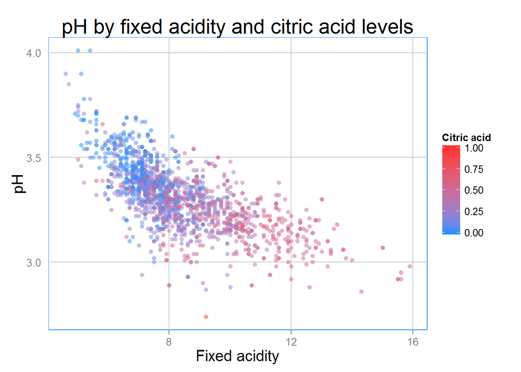

#### Description three

Citric acid is only found in *minute* quantities in wine grapes. More often citric acid gets added to wine after the fermentation process to remove excess copper and wine (according to [Wikipedia](https://en.wikipedia.org/wiki/Acids_in_wine#Citric_acid)). This graphs illustrates the link between pH and the acid levels very well. Stronger acids have lower pH values, and you can see here that adding citric acid to wine lowers the pH values.

### Conclusion

Rating the quality of wine can be quite a subjective process - everyone has his own preference. But having said that, there are definitely a few factors that can affect the taste of wine. The alcohol-, volatile acidity and sulphate- levels are the main culprits. And these features in turn get influenced by factors like the amount of citric acid added after fermentation, the chloride levels and the method of preservation (how much sulphate gets added if any). Fitting a linear model using these factors, accurately predicts 58% of the wines - which isn’t terrible bad. But using a linear model is not the best option, since the response variable is categorical. Perhaps it would be better to use a Naive Bayes model or build a decision tree instead. The Random Forest model provides the best ‘out of the box’ model, but it’s possible to improve on that. It would be interesting to see the cultivars of the wine. I think single origin wines or simple blends would have much higher levels of alcohol, since more complex blends can be fine-tuned to have more specific sulphate and alcohol levels. And obviously every type of grape has a different fermentation process which would different results. The main challange was to find features which have an impact on the quality of the wine. Considering that there are 12 features, it will be too much effort to plot every feature against every other feature to see what is worthwile to investigate and what not. The correlation matrix was a good starting to point to see what features are more relevant to the quality of the wines and what not.